# tp3

2023-03-27

# OLIVEIRA MOMBACH Aline, LI Maxime and PIOT Ghislain.

## TP 3 Classification with genetic markers

## Part 1: Data

```r
# read the data in the table "NAm2.txt". The header=TRUE argument specifies that the first row of the file contains the column names.
NAm2 = read.table("NAm2.txt", header=TRUE)

cont <- function(x){
  if(x %in% c('Canada'))
    cont <- 'NorthAmerica'
  else if(x %in% c('Guatemala', 'Mexico', 'Panama', 'CostaRica'))
    cont<-'CentralAmerica'
  else
     cont<-'SouthAmerica'
  return(factor(cont))
}
contID<-sapply(as.character(NAm2[,4]),FUN=cont)
levelscontID <- levels(contID)
```

## Part 2 : Multinomial regression

```r
NAcont <- cbind(contID=contID, NAm2[,-(1:8)])
NAcont[,1] <- factor(NAcont[,1])
```

```r
# model_first <- multinom(NAcont$contID~., data=NAcont, MaxNWts=18000, it=200)
```

The fit function crashes because the the multinom function has a default limit to prevent being too slow ( by trying to create a Neural Network with too many neurons in the hidden layer).

### b)

```r
pcaNAm2 = prcomp(NAcont[,-1], scale=F)
pcaCont = data.frame(cbind(contID=contID, pcaNAm2$x))

sample = sample.split(pcaCont[,1], SplitRatio = .90)
trainingSet = subset(pcaCont, sample == TRUE)
testingSet  = subset(pcaCont, sample == FALSE)


trainingSetcontID = trainingSet[,1]
testingSetcontID = testingSet[,1]

#testingSet = pcaCont[c(1:(length(pcaCont)/10)),]
#trainingSet = pcaCont[-c(1:(length(pcaCont)/10)),]
trainingContId = trainingSet[,1]
testContId = trainingSet[,1]
model <- multinom(pcaCont$contID ~ ., data = pcaCont, MaxNWts=18000, it=200)
predicted <- predict(model, pcaCont[,-1])
table(predicted, contID)
```

```
##          contID
## predicted NorthAmerica CentralAmerica SouthAmerica
##         1           67              0            0
##         2            0            159            0
##         3            0              0          268
```

We get a perfect confusion matrix, but this is to be expected because we are using our training data as validation data. By using all the primary components, we probably over fitted our model.

### c)

```r
setList <- sample(c(1:nrow(trainingSet)),size = nrow(trainingSet))%%10

noContId = trainingSet[,-1]

multinomCV <- function(naxes){
  validationError = 0  # Sum of validation error

  for (i in (0:9)){
    trainData = trainingSet[which(setList!=i),]
    testData = trainingSet[which(setList==i),]
    trainContId = trainingContId[which(setList != i)]
    pcaDataCurrent <- prcomp(trainData[,-1], scale=F ) # TODO
    pcaDataTest <- predict(pcaDataCurrent, newdata=testData[,-1])

    pcaModel = data.frame(pcaDataCurrent$x[,c(1:(1+naxes))])
    model <- multinom(trainContId ~., data = pcaModel, MaxNWts=10000, trace=F)
    trainingResult = predict(model, pcaDataTest)
    #print(nrow(trainData))
    validationError = validationError + sum( trainingResult != trainingContId[which(setList==i)])
  }
  result <- validationError / nrow(trainingSet)

  return(result)
}
multinomCV(100)
```

```
## [1] 0.06756757
```

```r
graphError <- function(crossValidation, name){
  naxesList <- seq(2, 400, by=10)
  validationError <-c()
  validationError <- foreach (i = 1:length(naxesList), .combine = c) %dopar%{
    crossValidation(naxesList[i])
  }
  validationError <- validationError*100
  plot(naxesList, validationError, main = paste(name, "Validation Error as a function of naxes"), xlab = "Number of predictors", ylab = "Prediction Error(%)", col = 3, type="l")
  abline(v=naxesList[which.min(validationError)], col = 2)
  minimum = naxesList[which.min(validationError)]
  cat("The model that minimize the validation Error have between", minimum - 9," and ", minimum + 9, "predictors\n")

  naxesList2 <- seq(max(0, minimum - 9), min(minimum + 9, 400))
  validationError2 <-c()
  validationError2 <- foreach (i = 1:length(naxesList2), .combine = c) %dopar%{
    #print(i)
    crossValidation(naxesList2[i])
  }
  validationError2 <- validationError2 * 100
  plot(naxesList2, validationError2, main = paste(name, "Validation Error as a function of naxes"), xlab = "Number of predictors", ylab = "Prediction Error(%)", col = 3, type="l")
  abline(v=naxesList2[which.min(validationError2)], col =2)
  cat("The model that minimize the prediction error have ", naxesList2[which.min(validationError2)], "predictors and the validation Error is ", min(validationError2),"%\n" )
  return (c(naxesList2[which.min(validationError2)],validationError))
}
```

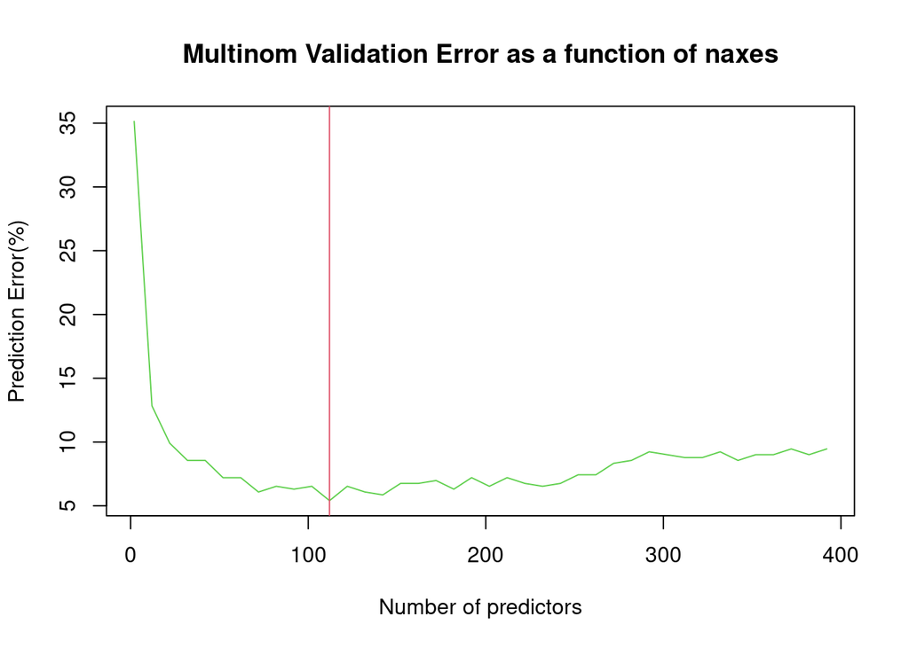

```
## The model that minimize the validation Error have between 103  and  121 predictors
```

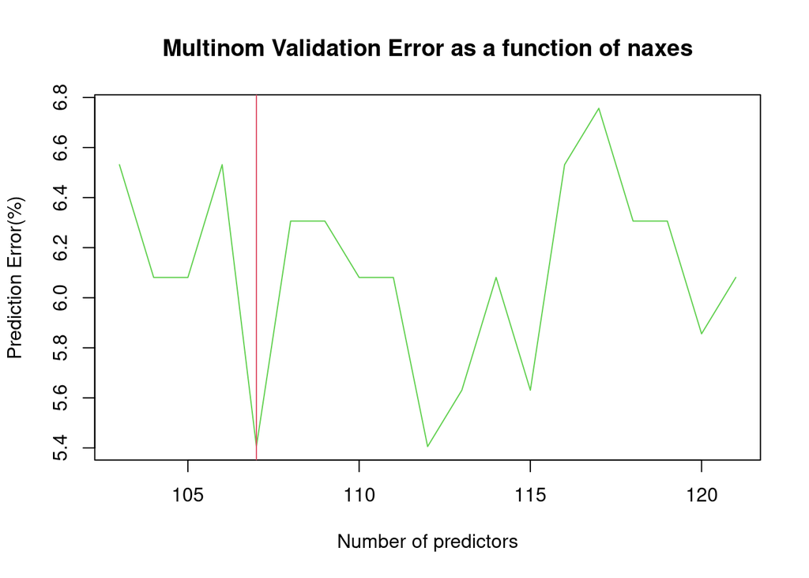

```
## The model that minimize the prediction error have  107 predictors and the validation Error is  5.405405 %
```

```r
multinomRes = graphError(multinomCV, "Multinom")
```

```r
multinomMin = multinomRes[1]
multinomError = multinomRes[-1]
```

#### d

```r
pcaNAm2 = prcomp(NAcont[,-1], scale=F)
pcaCont = data.frame(cbind(contID=contID, pcaNAm2$x))
modelMultinom <- multinom(pcaCont$contID ~ ., data = pcaCont[,c(1:multinomMin+1)], MaxNWts=18000, it=200)
predicted <- predict(modelMultinom, pcaCont[,-1])
table(predicted, contID)
```

```
##          contID
## predicted NorthAmerica CentralAmerica SouthAmerica
##         1           67              0            0
##         2            0            159            0
##         3            0              0          268
```

## Part 3 : Linear discriminant analysis

```r
ldaModel <- lda(pcaNAm2$x, grouping = pcaCont$contID , tol = 0)
#Set tolerance very small for PC494 or else we get "variable 494 appears to be constant within groups".

#summary(ldaModel)
predicted <- predict(ldaModel, pcaNAm2$x)$class
table(predicted, contID)
```

```
##          contID
## predicted NorthAmerica CentralAmerica SouthAmerica
##         1           67              0            0
##         2            0            159            0
##         3            0              0          268
```

```r
pcaDataCurrent <- prcomp(trainingSet[,-1], scale=F )
pcaDataTest <- predict(pcaDataCurrent, newdata=testingSet[,-1])

pcaModel = data.frame(pcaDataCurrent$x)
model <- lda(pcaModel , grouping = trainingSet[,1] , tol = 0.000000000000001)
trainingResult = predict(model, pcaDataTest)$class

table(trainingResult, testingSet[,1])
```

```
##
## trainingResult  1  2  3
##              1  2  9 15
##              2  5  7 12
##              3  0  0  0
```

We need to use a really small tolerance because the 444th PC is so small that it is recognized as a constant vector. We got really bad results (only 9 correctly predicted out of the testing set) because we used all the principal components and a very small tolerance. It results in overfitting the data, where the model is too complex and fits the noise in the data rather than the underlying patterns.

```r
ldaCV <- function(naxes, tol = 0.001){
  validationError = 0  # Sum of validation error

  r <- foreach (i = 0:9, .combine = c) %do% {
    trainData = trainingSet[which(setList!=i),]
    testData = trainingSet[which(setList==i),]
    trainContId = trainingContId[which(setList != i)]
    pcaDataCurrent <- prcomp(trainData[,-1], scale=F ) # TODO
    pcaDataTest <- predict(pcaDataCurrent, newdata=testData[,-1])

    pcaModel = data.frame(pcaDataCurrent$x[,c(1:(naxes))])
    model <- lda(pcaModel , grouping = trainContId , tol = tol)
    trainingResult = predict(model, pcaDataTest[,c(1:(naxes))])$class


    sum( trainingResult != trainingContId[which(setList==i)])
  }
  result <- sum(r) / nrow(trainingSet)
  return(result)
}
ldaCV(392)
```

```
## [1] 0.05855856
```

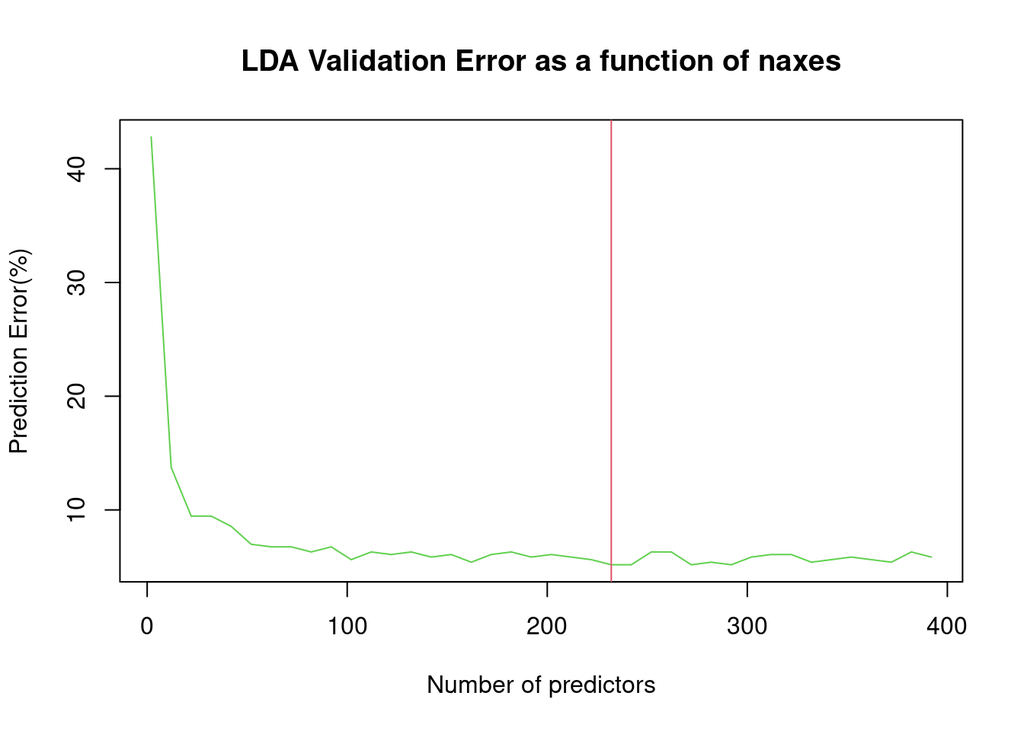

```
## The model that minimize the validation Error have between 223  and  241 predictors
```

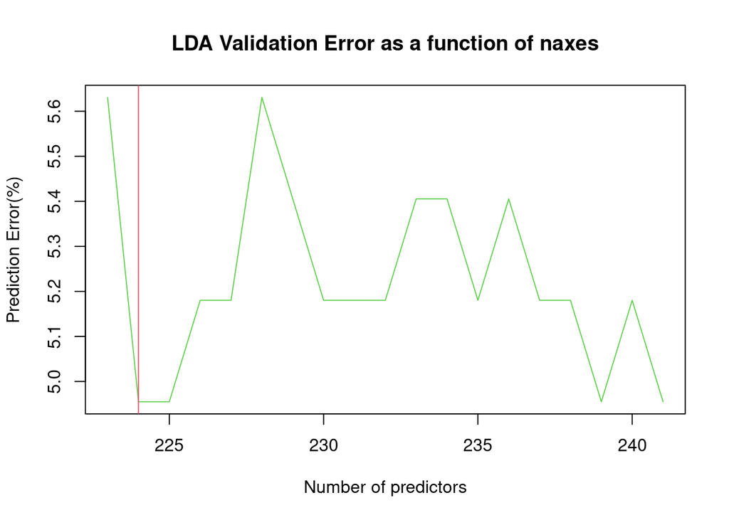

```
## The model that minimize the prediction error have  224 predictors and the validation Error is  4.954955 %
```

```r
ldaRes = graphError(ldaCV, "LDA")
```

```r
ldaMin = ldaRes[1]
ldaError = ldaRes[-1]
```

We can see that the Validation error seems to decrease greatly at first between 2 and 52 predictors, then seem to plateau until a certain point where the prediction error explodes. This point seems to depend on the tolerance given to the lda function. The greater the value, the earlier the boost. It is due to the fact that a higher tolerance tend to shrinks the estimated covariance matrices towards a diagonal matrix, and for a number of PCA too high, we lose too much information and underfit the data set

The tolerance affects the degree of regularization or shrinkage applied to the estimated covariance matrices, a high tolerance value shrinks the estimated covariance matrices towards a diagonal matrix, while a low tolerance value allows the estimated covariance matrices to be more complex.

Because of that it directly affect overfitting and underfitting : a high tolerance value can prevent overfitting by reducing the complexity of the estimated covariance matrices, while a low tolerance value can prevent underfitting by allowing the estimated covariance matrices to capture more complex relationships in the data.

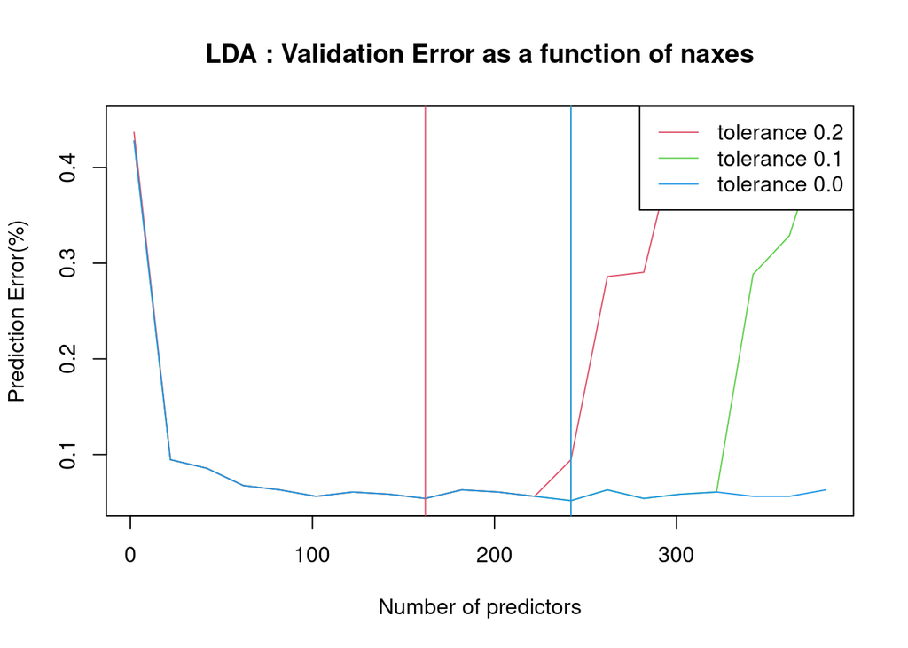

```r
naxesList <- seq(2, 400, by=20)
validationError <-c()
tolerance_0.1 <- foreach (i = 1:length(naxesList), .combine = c) %dopar%{
  ldaCV(naxesList[i], 0.1)
}
tolerance_0.2 <- foreach (i = 1:length(naxesList), .combine = c) %dopar%{
  ldaCV(naxesList[i], 0.2)
}
tolerance_0.0 <- foreach (i = 1:length(naxesList), .combine = c) %dopar%{
  ldaCV(naxesList[i], 0)
}


validationError <- validationError*100
plot(naxesList, tolerance_0.1, main = paste("LDA : Validation Error as a function of naxes"), xlab = "Number of predictors", ylab = "Prediction Error(%)", col = 3, type="l")
lines(naxesList, tolerance_0.2, col = 2)
lines(naxesList, tolerance_0.0, col = 4)
abline(v=naxesList[which.min(tolerance_0.1)], col = 3)
abline(v=naxesList[which.min(tolerance_0.2)], col = 2)
abline(v=naxesList[which.min(tolerance_0.0)], col = 4)
legend("topright", legend = c("tolerance 0.2", "tolerance 0.1", "tolerance 0.0"),lty = 1, col = c(2,3,4))
```

```r
#minimum = naxesList[which.min(validationError)]
```

We can see that for the tolerance à and 0.1, the minimum is at the same place and the prediction error seems to be the same for the 3 tolerance before their jump.

```r
pcaDataCurrent <- prcomp(trainingSet[,-1], scale=F ) # TODO
pcaDataTest <- predict(pcaDataCurrent, newdata=testingSet[,-1])
pcaModel = data.frame(pcaDataCurrent$x[,c(1:(1+ldaMin))])
model <- lda(pcaModel , grouping = trainingContId , tol = 0.001)
trainingResult = predict(model, pcaDataTest[,c(1:(1+ldaMin))])$class

table(trainingResult, testingSet[,1])
```

```
##
## trainingResult  1  2  3
##              1  7  0  0
##              2  0 16  0
##              3  0  0 27
```

The model is greatly more efficient than with all the components (we have no mistake here, but it may be due to the testing set size). Because we give up the less important and noisier components, the model overfit much less the data and the noise.

Also the last PCAs tend to be more affected by the tolerance (A tolerance to decide if a matrix is singular; it will reject variables and linear combinations of unit-variance variables whose variance is less than tol^2. ) because their values are much smaller than the first ones.

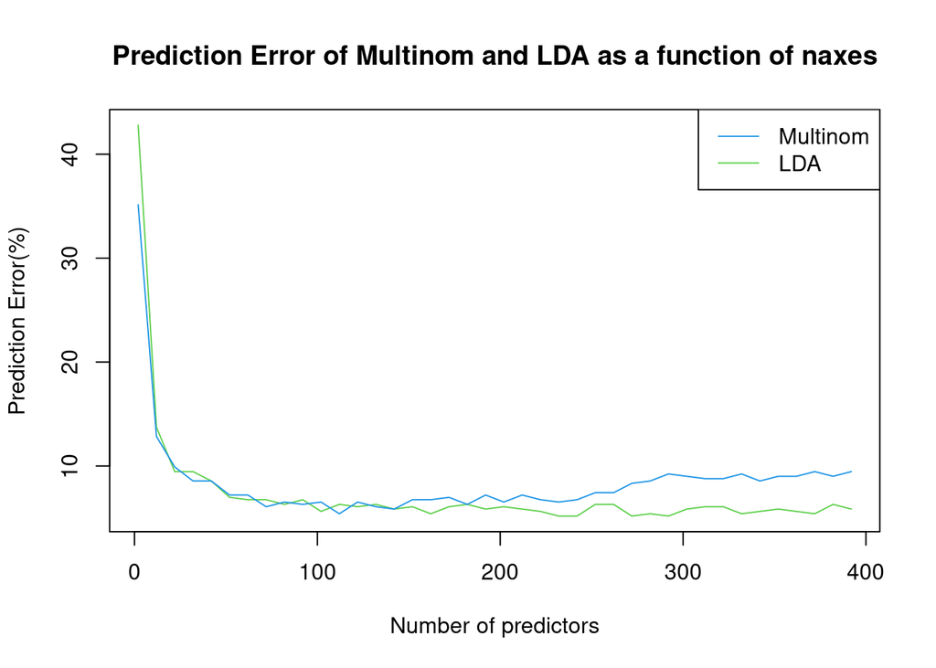

```r
naxesList <- seq(2, 400, by=10)
plot(naxesList, ldaError, main = "Prediction Error of Multinom and LDA as a function of naxes", xlab = "Number of predictors", ylab = "Prediction Error(%)" , col = 3, type ="l")
lines(naxesList,multinomError, col = 4)
legend("topright", legend = c("Multinom", "LDA"),lty = 1, col = c(4,3))
```

We can see that the lda seems to outperform his counterpart by 0.45% and doesn’t overfit as much as the multinom model with a small enough tolerance. But from a certain point depending on the tolerance, the prediction error explode because we shrink the estimated covariance matrices towards a diagonal matrix too much, and for a number of PCA too high, we lose too much information and underfit the data set.